### Load Libraries

```r
# load libraries
library(tidyverse)
library(caret)
```

```r
library(rpart)
library(rpart.plot)
library(glmnet)
```

### Data Exploration

```r
# set random seed, for reproducibility
set.seed(101)
```

```r
# load data (store back-up copy for possible backtracking and/or reference later)
original.train <- read.csv("Data/train.csv", stringsAsFactors = TRUE)
original.test <- read.csv("Data/test.csv", stringsAsFactors = TRUE)

data.train <- read.csv("Data/train.csv", stringsAsFactors = TRUE)
data.test <- read.csv("Data/test.csv", stringsAsFactors = TRUE)
```

#### Summary of Data

```r
# observe dataset structure
str(data.train)
```

```
## 'data.frame':    891 obs. of  12 variables:
##  $ PassengerId: int  1 2 3 4 5 6 7 8 9 10 ...
##  $ Survived   : int  0 1 1 1 0 0 0 0 1 1 ...
##  $ Pclass     : int  3 1 3 1 3 3 1 3 3 2 ...
##  $ Name       : Factor w/ 891 levels "Abbing, Mr. Anthony",..: 109 191 358 277 16 559 520 629 417 581 ...
##  $ Sex        : Factor w/ 2 levels "female","male": 2 1 1 1 2 2 2 2 1 1 ...
##  $ Age        : num  22 38 26 35 35 NA 54 2 27 14 ...
##  $ SibSp      : int  1 1 0 1 0 0 0 3 0 1 ...
##  $ Parch      : int  0 0 0 0 0 0 0 1 2 0 ...
##  $ Ticket     : Factor w/ 681 levels "110152","110413",..: 524 597 670 50 473 276 86 396 345 133 ...
##  $ Fare       : num  7.25 71.28 7.92 53.1 8.05 ...
##  $ Cabin      : Factor w/ 148 levels "","A10","A14",..: 1 83 1 57 1 1 131 1 1 1 ...
##  $ Embarked   : Factor w/ 4 levels "","C","Q","S": 4 2 4 4 4 3 4 4 4 2 ...
```

```r
# summary stats of training data
summary(data.train)
```

```
##   PassengerId       Survived          Pclass
##  Min.   :  1.0   Min.   :0.0000   Min.   :1.000
##  1st Qu.:223.5   1st Qu.:0.0000   1st Qu.:2.000
##  Median :446.0   Median :0.0000   Median :3.000
##  Mean   :446.0   Mean   :0.3838   Mean   :2.309
##  3rd Qu.:668.5   3rd Qu.:1.0000   3rd Qu.:3.000
##  Max.   :891.0   Max.   :1.0000   Max.   :3.000
##
##                                     Name         Sex           Age
##  Abbing, Mr. Anthony                  :  1   female:314   Min.   : 0.42
##  Abbott, Mr. Rossmore Edward          :  1   male  :577   1st Qu.:20.12
##  Abbott, Mrs. Stanton (Rosa Hunt)     :  1                Median :28.00
##  Abelson, Mr. Samuel                  :  1                Mean   :29.70
##  Abelson, Mrs. Samuel (Hannah Wizosky):  1                3rd Qu.:38.00
##  Adahl, Mr. Mauritz Nils Martin       :  1                Max.   :80.00
##  (Other)                              :885                NA's   :177
##      SibSp           Parch             Ticket         Fare
##  Min.   :0.000   Min.   :0.0000   1601    :  7   Min.   :  0.00
##  1st Qu.:0.000   1st Qu.:0.0000   347082  :  7   1st Qu.:  7.91
##  Median :0.000   Median :0.0000   CA. 2343:  7   Median : 14.45
##  Mean   :0.523   Mean   :0.3816   3101295 :  6   Mean   : 32.20
##  3rd Qu.:1.000   3rd Qu.:0.0000   347088  :  6   3rd Qu.: 31.00
##  Max.   :8.000   Max.   :6.0000   CA 2144 :  6   Max.   :512.33
##                                   (Other) :852
##          Cabin     Embarked
##             :687    :  2
##  B96 B98    :  4   C:168
##  C23 C25 C27:  4   Q: 77
##  G6         :  4   S:644
##  C22 C26    :  3
##  D          :  3
##  (Other)    :186
```

```r
# calculate the mean survival rate on the training set, and calculate the no-information rate rate, which will be our baseline
paste("Mean Survival Rate:", round(mean((as.logical(data.train$Survived))), 4))
```

```
## [1] "Mean Survival Rate: 0.3838"
```

```r
writeLines("")
```

```r
print(paste("No-information Rate:", round(max(mean((as.logical(data.train$Survived))), 1 - mean((as.logical(data.train$Survived)))), 4)))
```

```
## [1] "No-information Rate: 0.6162"
```

#### Data Cleaning and Feature Generation

##### Convert Variable Types

```r
# convert variables to appropriate type
data.train$Survived <- as.logical(data.train$Survived)
data.train$Pclass <- as.factor(data.train$Pclass)
data.train$Name <- as.character(data.train$Name)
data.train$Ticket <- as.character(data.train$Ticket)
data.train$Cabin <- as.character(data.train$Cabin)

data.test$Pclass <- as.factor(data.test$Pclass)
data.test$Name <- as.character(data.test$Name)
data.test$Ticket <- as.character(data.test$Ticket)
data.test$Cabin <- as.character(data.test$Cabin)
```

##### Transformations

```r
# transform the fare variable, since it's right-skewed
data.train$Fare <- ifelse(data.train$Fare >= 1, log(data.train$Fare), 0)
data.test$Fare <- ifelse(data.test$Fare >= 1, log(data.test$Fare), 0)
data.test$Fare <- ifelse(is.na(data.test$Fare), 0, data.test$Fare)
```

##### Feature Generation

```r
# generate dummy variables to capture the signal inherent in the passengers' names; then, delete the name variable [train]
data.train$isMr <- grepl("Mr\\.", data.train$Name)
data.train$isMrs <- grepl("Mrs\\.", data.train$Name)
data.train$isMaster <- grepl("Master\\.", data.train$Name)
data.train$isMiss <- grepl("Miss\\.", data.train$Name)

data.train$hasParenth <- grepl("\\(", data.train$Name)
data.train$hasQuote <- grepl("\"", data.train$Name)

data.train$Name <- NULL
```

```r
# generate dummy variables to capture the signal inherent in the passengers' names; then, delete the name variable [test]
data.test$isMr <- grepl("Mr\\.", data.test$Name)
data.test$isMrs <- grepl("Mrs\\.", data.test$Name)
data.test$isMaster <- grepl("Master\\.", data.test$Name)
data.test$isMiss <- grepl("Miss\\.", data.test$Name)

data.test$hasParenth <- grepl("\\(", data.test$Name)
data.test$hasQuote <- grepl("\"", data.test$Name)

data.test$Name <- NULL
```

```r
# generate dummy variables from ticket and cabin variables, then delete original variables [train]

# dealing with ticket number
data.train$fiveCharTicket <- nchar(data.train$Ticket) == 5
data.train$sixCharTicket <- nchar(data.train$Ticket) == 6
data.train$numericTicket <- !grepl("[A-Za-z]", data.train$Ticket)
data.train$ticketLength <- nchar(data.train$Ticket)
data.train$Ticket <- NULL

# dealing with cabin number
data.train$hasCabin <- grepl("[A-Z]", data.train$Cabin)
data.train$multiCabin <- grepl(" [A-Z]", data.train$Cabin)
data.train$Cabin <- NULL
```

```r
# generate dummy variables from ticket and cabin variables, then delete original variables [test]

# dealing with ticket number
data.test$fiveCharTicket <- nchar(data.test$Ticket) == 5
data.test$sixCharTicket <- nchar(data.test$Ticket) == 6
data.test$numericTicket <- !grepl("[A-Za-z]", data.test$Ticket)
data.test$ticketLength <- nchar(data.test$Ticket)
data.test$Ticket <- NULL

# dealing with cabin number
data.test$hasCabin <- grepl("[A-Z]", data.test$Cabin)
data.test$multiCabin <- grepl(" [A-Z]", data.test$Cabin)
data.test$Cabin <- NULL
```

```r
# new feature for those who didn't pay to ride
data.train$freeRide <- data.train$Fare == 0
data.test$freeRide <- data.test$Fare == 0
```

```r
# feature for if the passenger had no family with them
data.train$isAlone <- (data.train$SibSp + data.train$Parch) == 0
data.test$isAlone <- (data.test$SibSp + data.test$Parch) == 0
```

##### Imputing Missing Values

```r
# some missing ports of embarkation in the training data
data.train %>% filter(!Embarked %in% c("C", "Q", "S"))
```

```
##   PassengerId Survived Pclass    Sex Age SibSp Parch     Fare Embarked  isMr
## 1          62     TRUE      1 female  38     0     0 4.382027          FALSE
## 2         830     TRUE      1 female  62     0     0 4.382027          FALSE
##   isMrs isMaster isMiss hasParenth hasQuote fiveCharTicket sixCharTicket
## 1 FALSE    FALSE   TRUE      FALSE    FALSE          FALSE          TRUE
## 2  TRUE    FALSE  FALSE       TRUE    FALSE          FALSE          TRUE
##   numericTicket ticketLength hasCabin multiCabin freeRide isAlone
## 1          TRUE            6     TRUE      FALSE    FALSE    TRUE
## 2          TRUE            6     TRUE      FALSE    FALSE    TRUE
```

```r
# only two records, so not a big deal, but let's just impute using the most common port
data.train$Embarked[data.train$Embarked == ""] <- names(which.max(table(data.train$Embarked)))[1]
data.train$Embarked <- droplevels(data.train$Embarked)
```

```r
# not a problem on the test set
data.test %>% filter(!Embarked %in% c("C", "Q", "S"))
```

```
##  [1] PassengerId    Pclass         Sex            Age            SibSp
##  [6] Parch          Fare           Embarked       isMr           isMrs
## [11] isMaster       isMiss         hasParenth     hasQuote       fiveCharTicket
## [16] sixCharTicket  numericTicket  ticketLength   hasCabin       multiCabin
## [21] freeRide       isAlone
## <0 rows> (or 0-length row.names)
```

```r
# one NA to fix in the fare variable of the test set; just impute using the median (right-skewed), since it's only one point
#data.test[!complete.cases(data.test),]
#data.test$Fare[!complete.cases(data.test)] <- median(data.test$Fare, na.rm = TRUE)
```

```r
# missing ages: 177/891 records = nearly 20% of the data... this is problematic, for sure. need to impute values.
#data.train %>% filter(is.na(data.train$Age))
```

```r
# knn-imputation on age and center/scale all numeric vars
preProcValues <- preProcess(data.train,
                            method = c("knnImpute"),
                            k = 20,
                            knnSummary = mean)

data.train$imputedAge <- predict(preProcValues, data.train)$Age

# create a weights variable to limit the extent to which observations whose age variable was originally missing and subsequently imputed
w <- 0.9 # for easy reference in other code chunks
data.train$ageWeight<- rep(1, nrow(data.train))
data.train$ageWeight[is.na(data.train$Age)] <- w

# create a new iteration of the training data for backtracking, if need be
data.train2 <- data.train %>% select(-Age)
```

```r
# knn-imputation on age for the test set; same process as the one above for the train set
# there is no data leakage here because we're just using the information about the other
# passenger in the set (known beforehand) to approximate age
preProcValues <- preProcess(data.test,
                            method = c("knnImpute"),
                            k = 20,
                            knnSummary = mean)

data.test$imputedAge <- predict(preProcValues, data.test)$Age

rm(preProcValues)

data.test$ageWeight<- rep(1, nrow(data.test))
data.test$ageWeight[is.na(data.test$Age)] <- w

data.test2 <- data.test %>% select(-Age)
```

##### Scale Numeric Variables

```r
# scale numeric variables
data.train2$SibSp <- scale(data.train2$SibSp)
data.train2$Parch <- scale(data.train2$Parch)
data.train2$ticketLength <- scale(data.train2$ticketLength)

data.test2$SibSp <- scale(data.test2$SibSp)
data.test2$Parch <- scale(data.test2$Parch)
data.test2$ticketLength <- scale(data.test2$ticketLength)
```

##### Remove Non-Predictive Variables

```r
# remove PassengerId variable for now; store test ID's for final predictions
data.train2$PassengerId <- NULL

PassengerId <- data.test2$PassengerId
data.test2$PassengerId <- NULL
```

#### Visualizing Possible Features

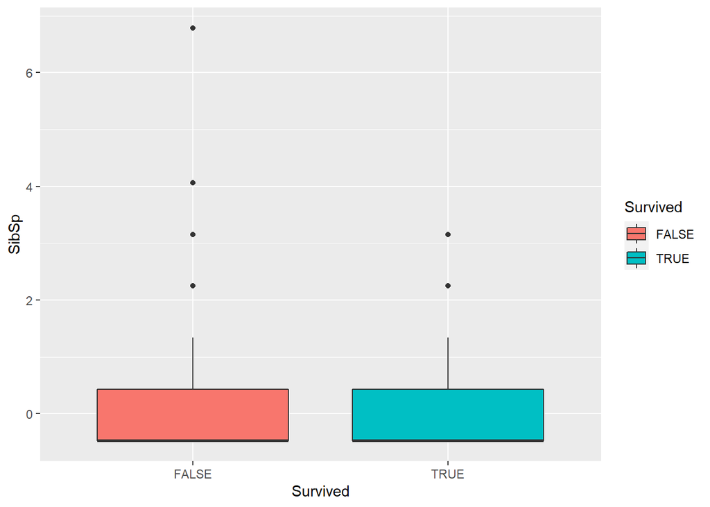

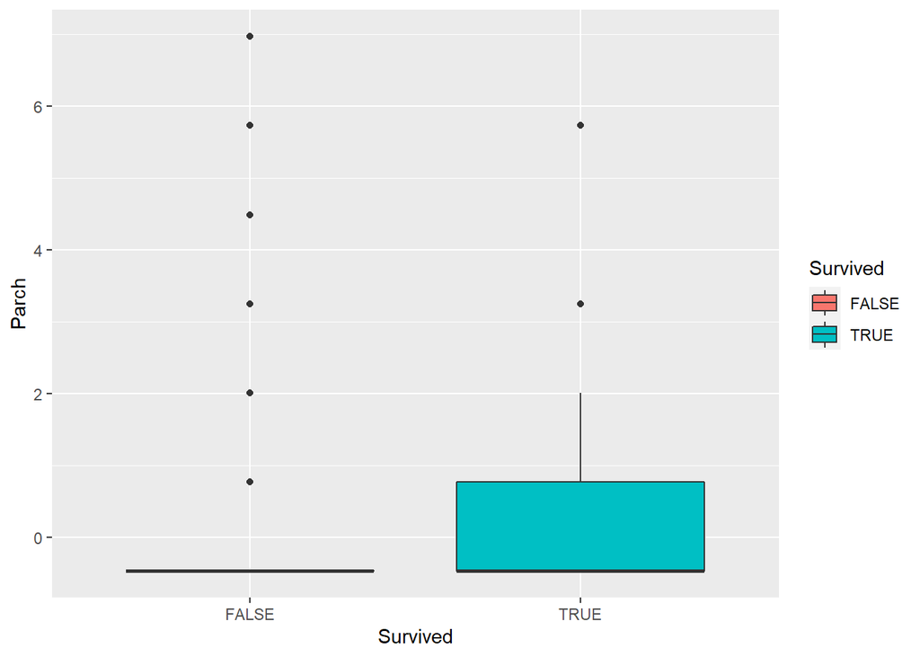

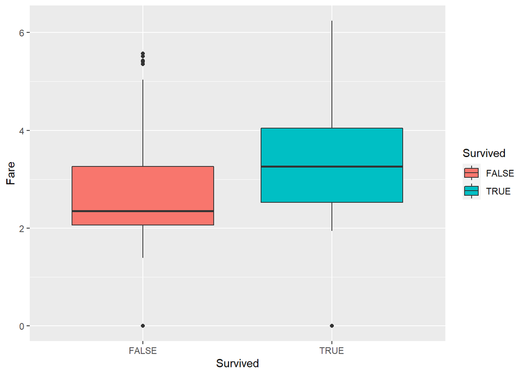

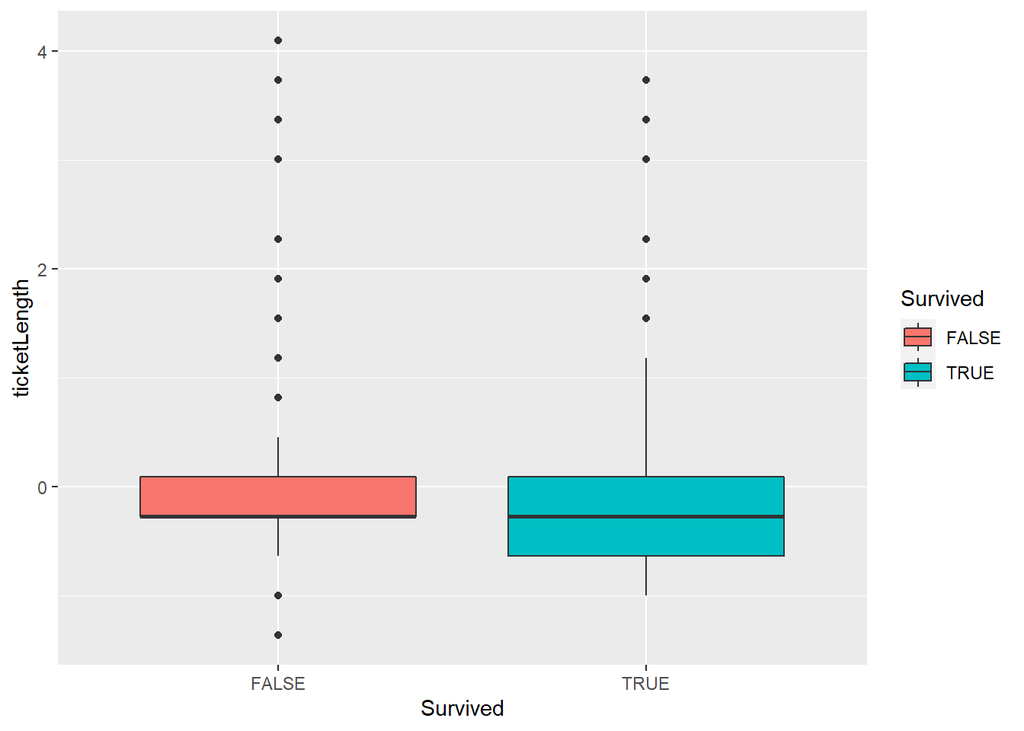

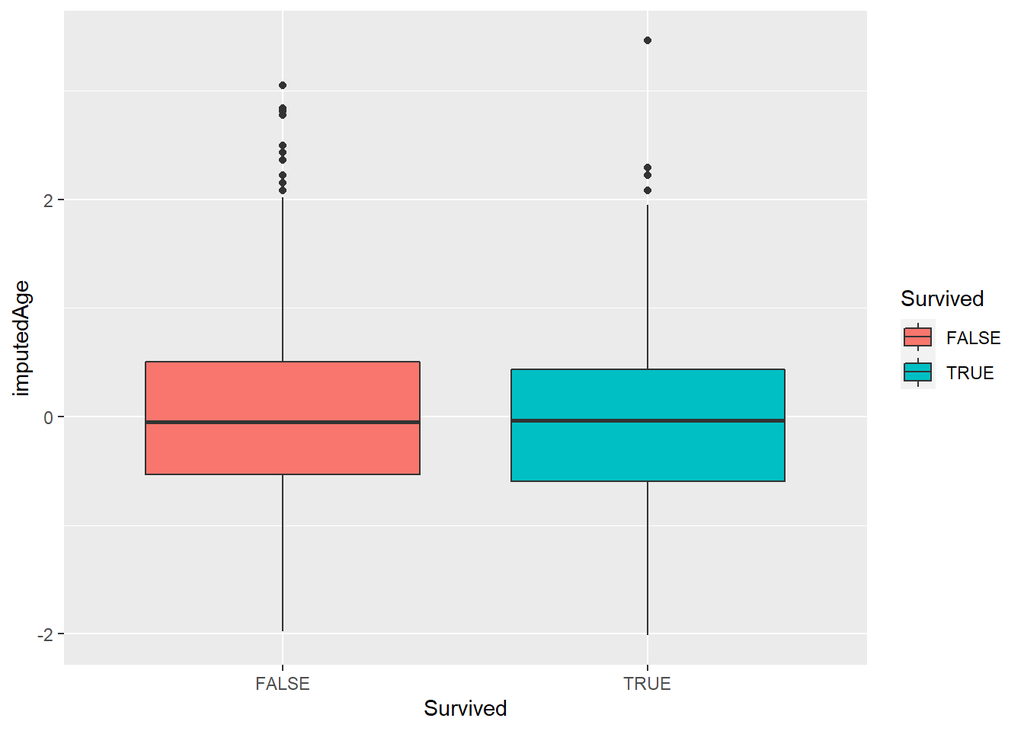

```r
# split boxplots for numeric variables
d <- data.train2 %>% select_if(is.numeric) %>% select(-ageWeight)

for (i in 1:ncol(d)) {
  print(ggplot(data.train2, aes_string("Survived", names(d)[i], fill = "Survived")) + geom_boxplot())
}
```

sibSp doesn’t appear to be providing any signal. the same can be said of age.

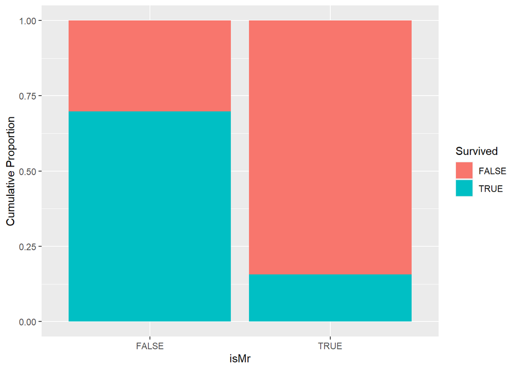

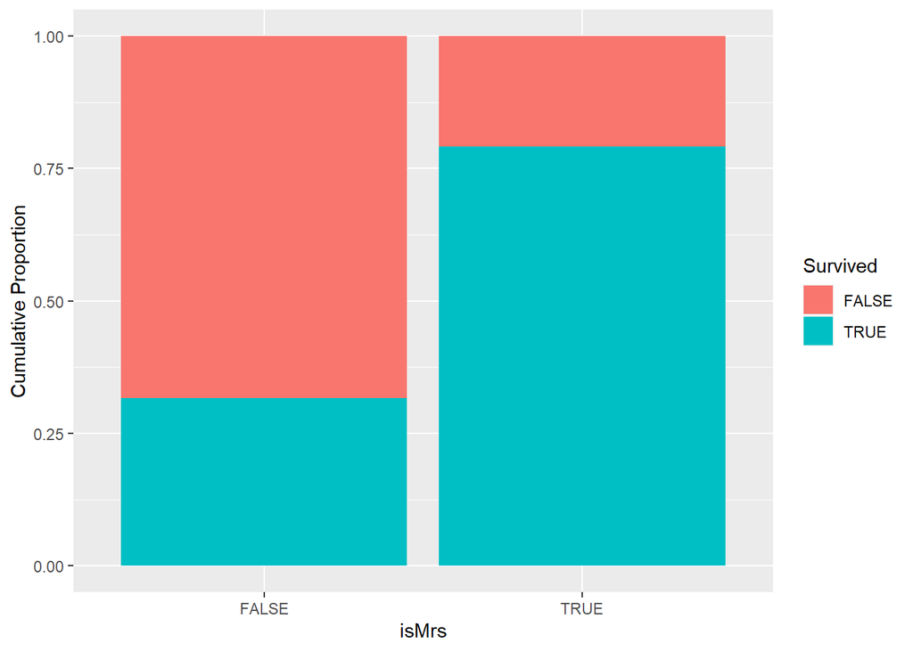

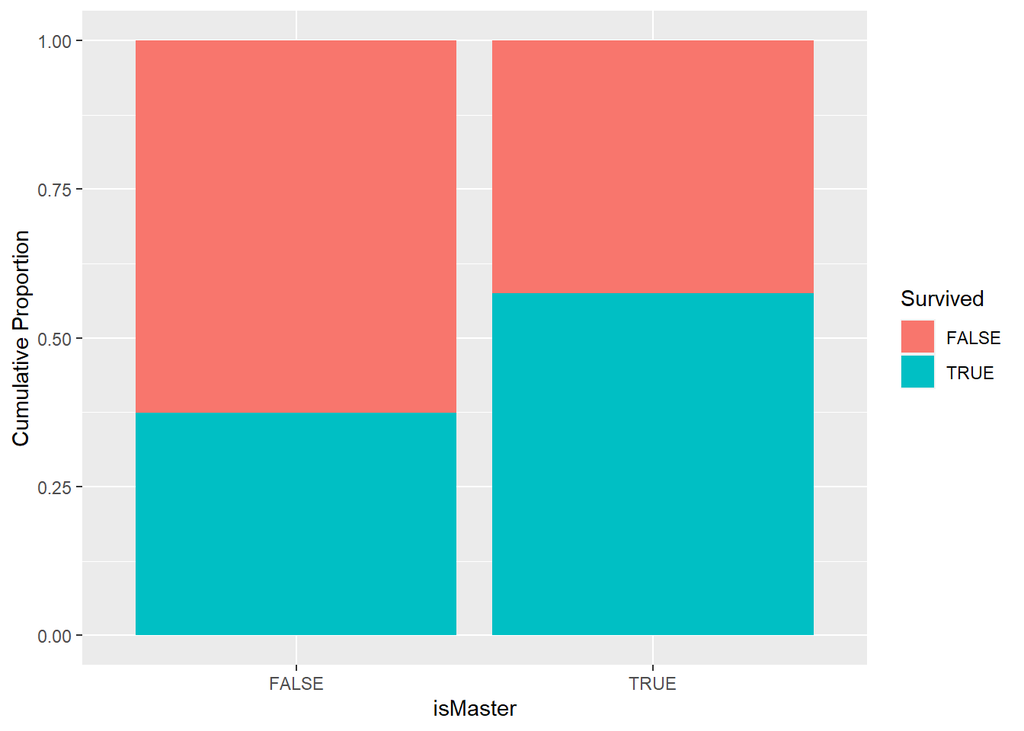

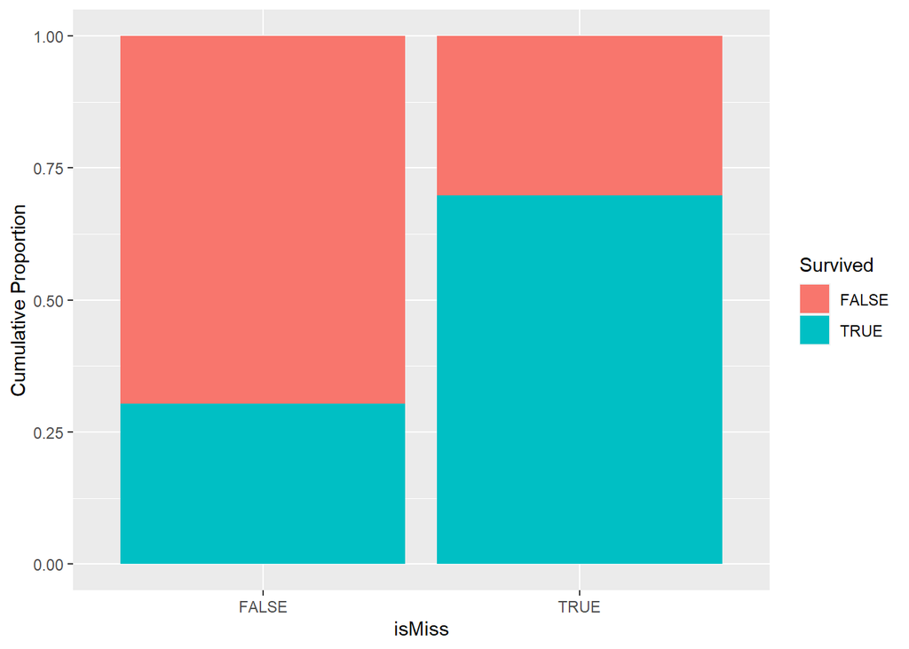

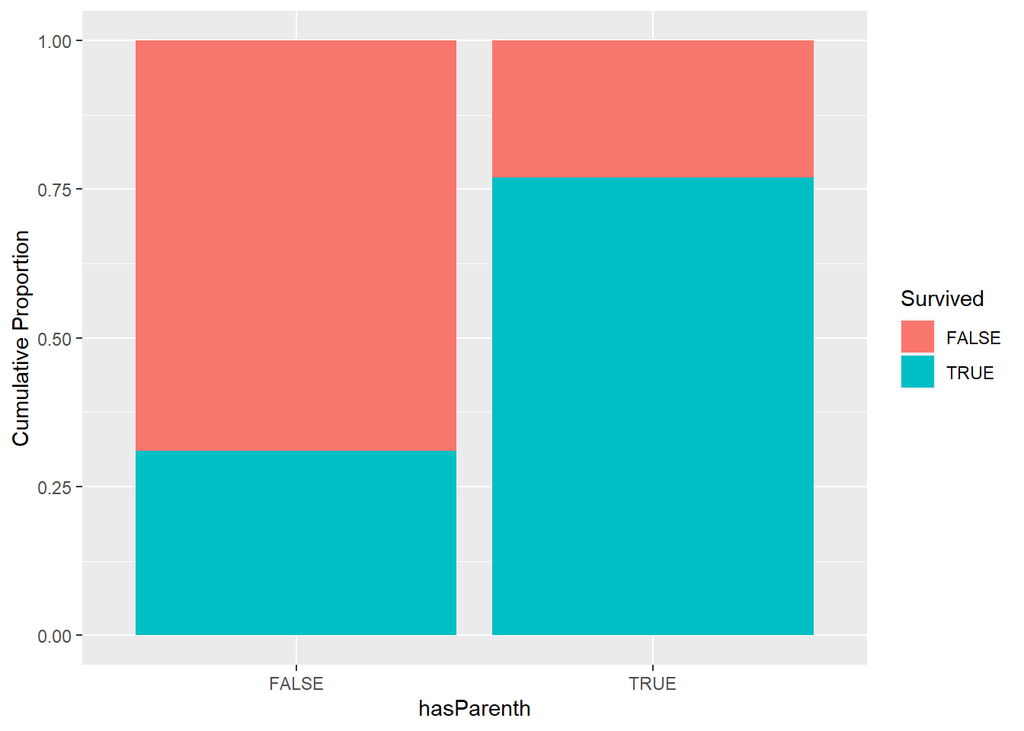

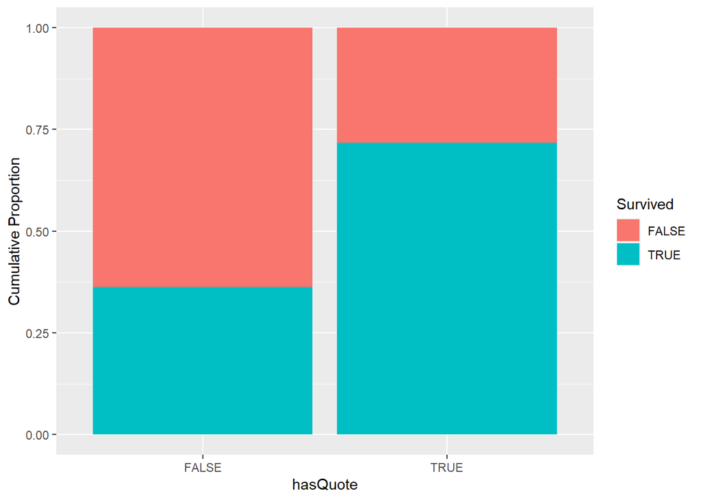

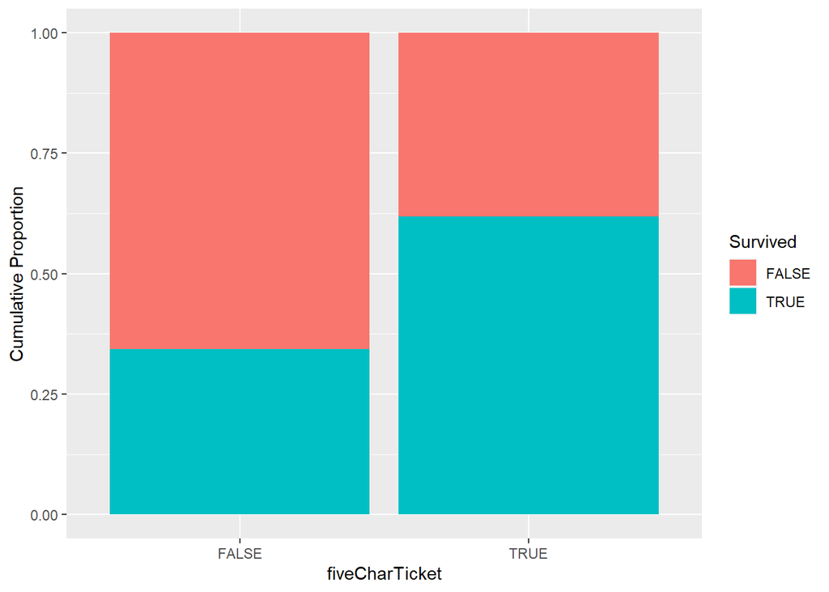

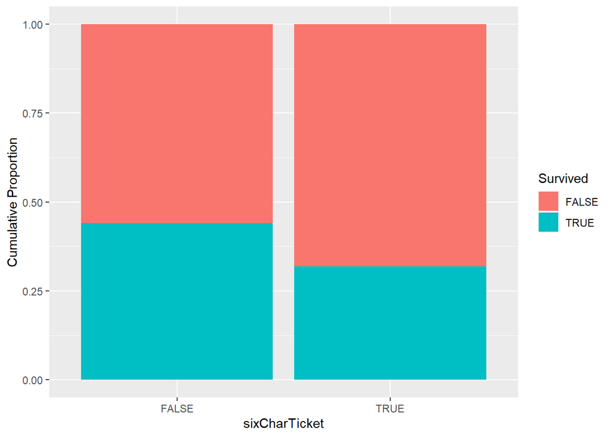

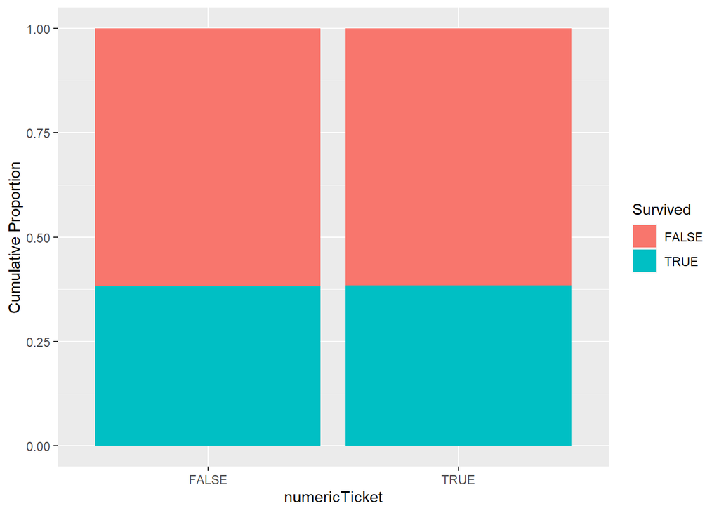

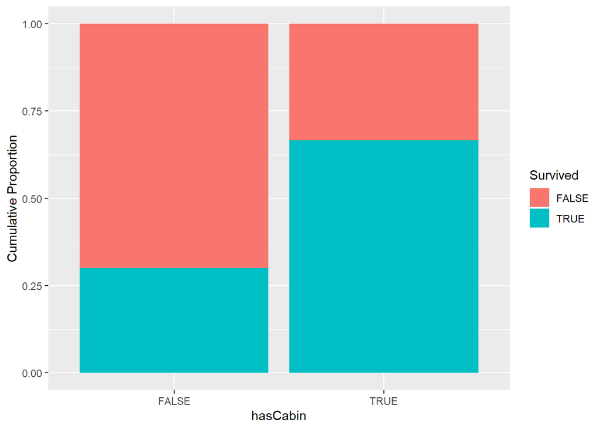

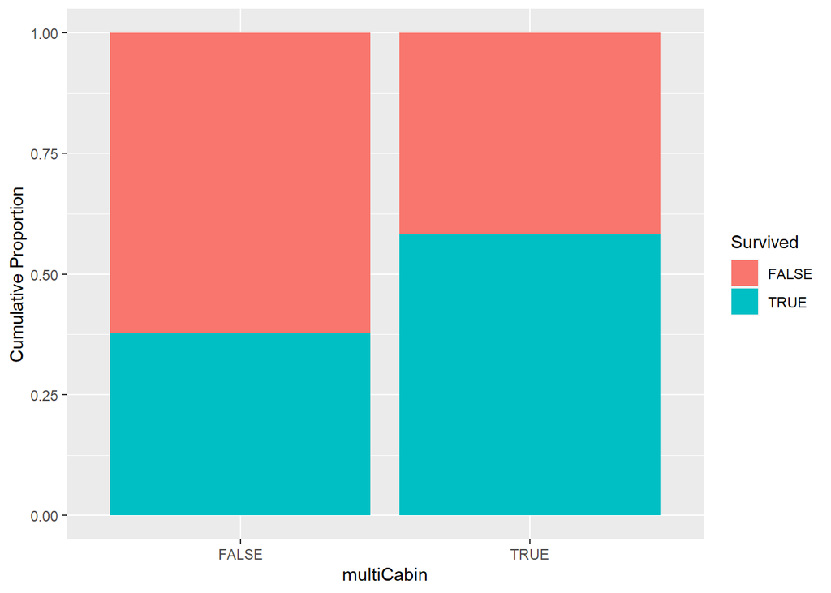

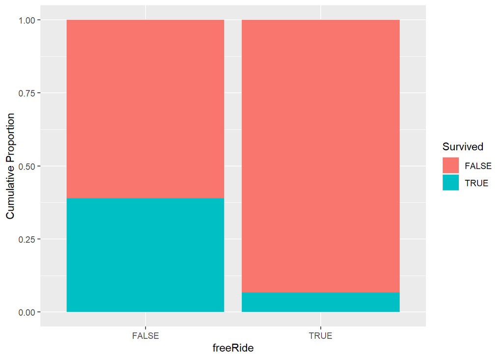

[1 more figures not shown]

```r
# split bar charts of logical variables

d <- data.train2 %>% select_if(is.logical)

for (i in 2:ncol(d)) {
  print(ggplot(data.train2, aes_string(names(d)[i], fill = "Survived")) + geom_bar(position = "fill") + labs(y = "Cumulative Proportion"))
}
```

It looks like most of the logical predictors will be useful as features. We probably won’t use sixCharTicket and numericTicket to avoid overfitting.

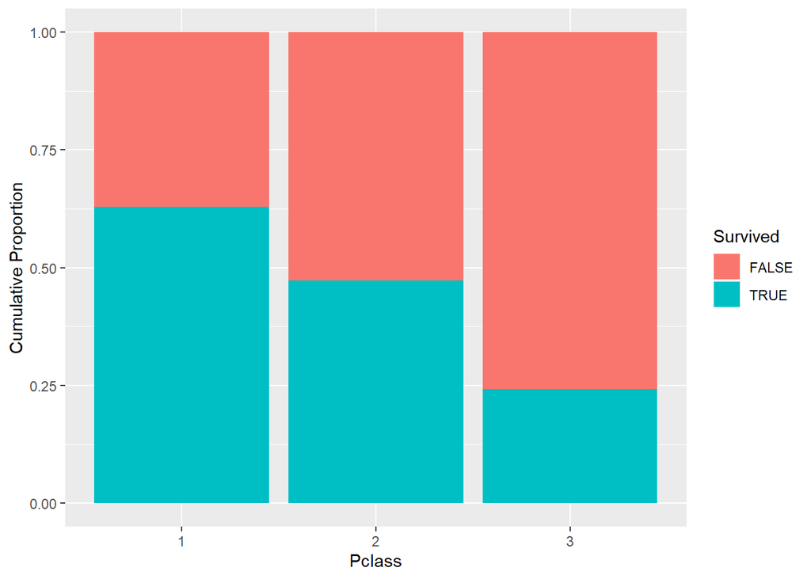

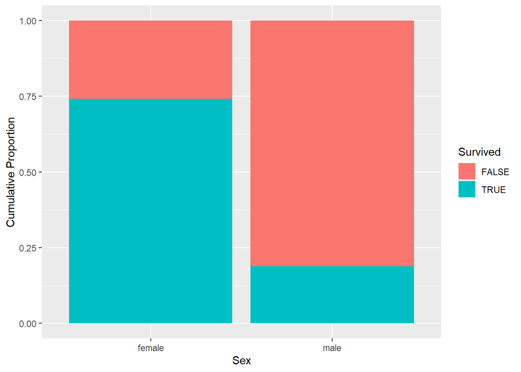

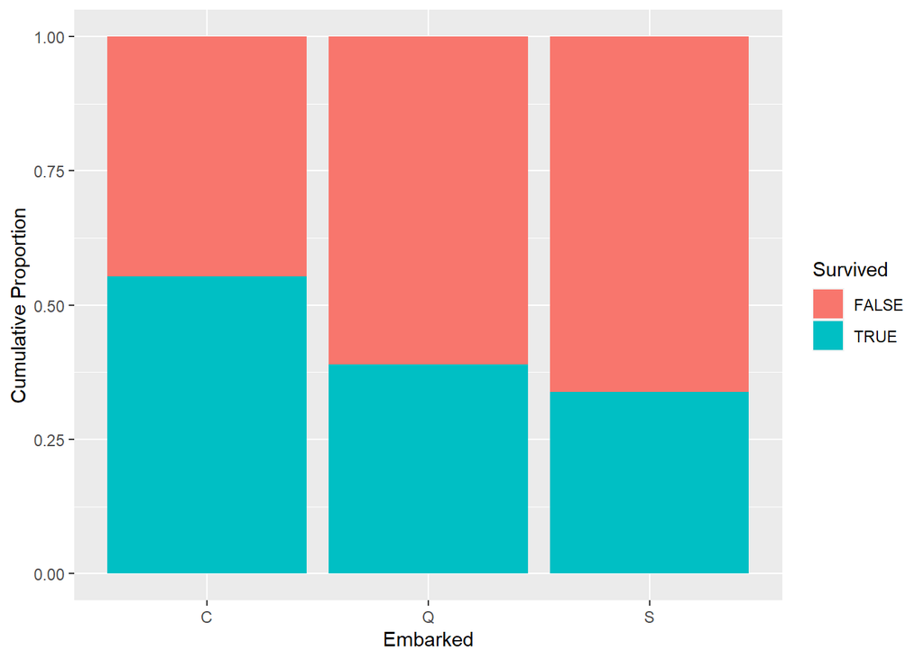

```r
# split bar charts for the each of the factors

d <- data.train2 %>% select_if(is.factor)

for (i in 1:ncol(d)) {
  print(ggplot(data.train2, aes_string(names(d)[i], fill = "Survived")) + geom_bar(position = "fill") + labs(y = "Cumulative Proportion"))
}
```

Each of these appears to have some good signal in it. we’ll use them all in our models.

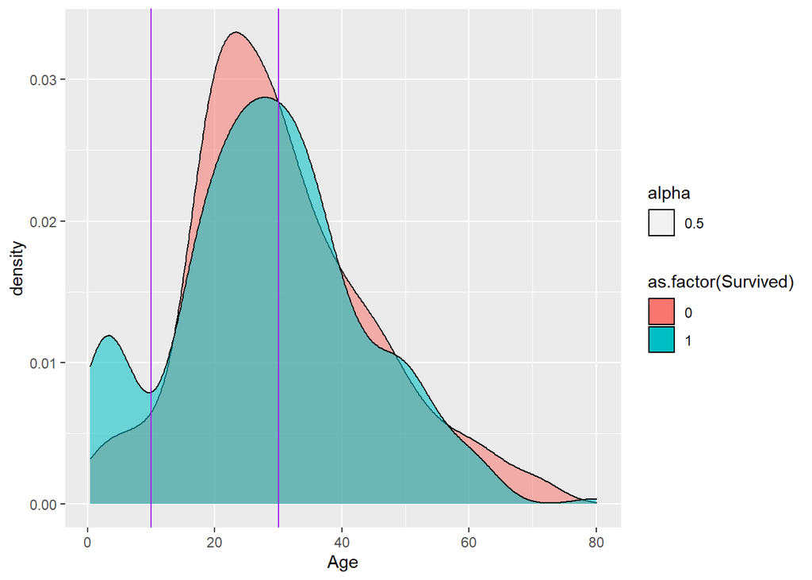

```r
# see if there's anything that can be salvaged from the age variable
ggplot(original.train, aes(Age)) + geom_density(aes(fill = as.factor(Survived), alpha = 0.5)) +
  geom_vline(xintercept = 10, color = "purple") + geom_vline(xintercept = 30, color = "purple")
```

```r
nrow(original.train %>% filter(Age < 10)) / nrow(original.train)
```

```
## [1] 0.06958474
```

Though there appears to be some signal (difference between probability density over different target values) for age < 10, this only comprises about 7% of the observations. With that said, we’ll just omit the data variable from our models. For that reason, we’ll also forgo the use of the ageWeight variable in our models as a counterbalance for imputation.

UPDATE: What if we compress that signal for ages 0-10, 10-30, and 30+ into two (omit the third level to avoid multicollinearity – specifically, rank deficiency due to perfect multicollinearity) binary variable, rather than discarding age altogether?

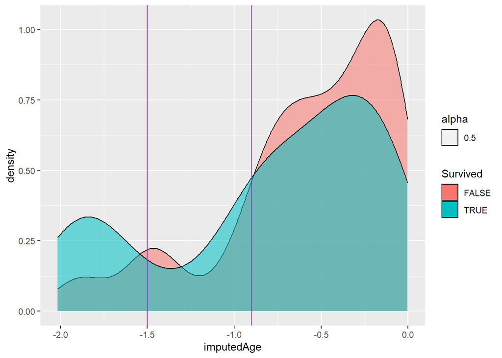

```r
# the age distribution is actually much different for those who survived and those who didn't, given the passenger's age was below average (scaled age = 0)
ggplot(data.train2 %>% filter(imputedAge < 0), aes(imputedAge, fill = Survived)) +
  geom_density(aes(alpha = 0.5)) +
  geom_vline(xintercept = -0.9, color = "purple") +
  geom_vline(xintercept = -1.5, color = "purple")
```

```r
# let's construct two binary variables to capture this signal

data.train2$isYouth <- ifelse(data.train2$imputedAge < -0.9, TRUE, FALSE)
data.train2$isYoungAdult <- ifelse(data.train2$imputedAge > -0.9 & data.train2$imputedAge < 0, TRUE, FALSE)

data.test2$isYouth <- ifelse(data.test2$imputedAge < -0.9, TRUE, FALSE)
data.test2$isYoungAdult <- ifelse(data.test2$imputedAge > -0.9 & data.test2$imputedAge < 0, TRUE, FALSE)
```

#### Feature Selection

```r
# reduce our training set based on observations above

data.train3 <- data.train2 %>% select(-c("SibSp", "imputedAge", "sixCharTicket", "numericTicket", "ageWeight"))
data.test3 <- data.test2 %>% select(-c("SibSp", "imputedAge", "sixCharTicket", "numericTicket", "ageWeight"))
```

### Model Building

#### GLM (Logistic Regression)

```r
# glm using binomial family with the canonical link (logit) -> logistic regression
fitGLM <- glm(Survived ~ ., data.train3, family = binomial)
confusionMatrix(as.factor(predict(fitGLM, type = "response") > 0.5), as.factor(data.train3$Survived), positive = "TRUE")
```

```
## Confusion Matrix and Statistics
##
##           Reference
## Prediction FALSE TRUE
##      FALSE   482   79
##      TRUE     67  263
##
##                Accuracy : 0.8361
##                  95% CI : (0.8102, 0.8599)
##     No Information Rate : 0.6162
##     P-Value [Acc > NIR] : <2e-16
##
##                   Kappa : 0.6513
##
##  Mcnemar's Test P-Value : 0.3626
##
##             Sensitivity : 0.7690
##             Specificity : 0.8780
##          Pos Pred Value : 0.7970
##          Neg Pred Value : 0.8592
##              Prevalence : 0.3838
##          Detection Rate : 0.2952
##    Detection Prevalence : 0.3704
##       Balanced Accuracy : 0.8235
##
##        'Positive' Class : TRUE
##
```

Not too bad. Correctly classifies 84% of training data. Significantly better than the no-information rate.

```r
# generate glm prediction for test set (probability > 0.5 -> Survived = TRUE)
fitGLM.predictions <- predict(fitGLM, data.test3, type = "response") > 0.5
mean(fitGLM.predictions)
```

```
## [1] 0.4019139
```

#### Classification Tree

```r
# build an unpruned (cp = 0) decision tree
fitTree <- rpart(Survived ~ ., data.train3, method = "class",
                 control = rpart.control(cp = 0))

confusionMatrix(as.factor(predict(fitTree, type = "class")), as.factor(data.train3$Survived), positive = "TRUE")
```

```
## Confusion Matrix and Statistics
##
##           Reference
## Prediction FALSE TRUE
##      FALSE   497   67
##      TRUE     52  275
##
##                Accuracy : 0.8664
##                  95% CI : (0.8423, 0.8881)
##     No Information Rate : 0.6162
##     P-Value [Acc > NIR] : <2e-16
##
##                   Kappa : 0.7153
##
##  Mcnemar's Test P-Value : 0.1994
##
##             Sensitivity : 0.8041
##             Specificity : 0.9053
##          Pos Pred Value : 0.8410
##          Neg Pred Value : 0.8812
##              Prevalence : 0.3838
##          Detection Rate : 0.3086
##    Detection Prevalence : 0.3670
##       Balanced Accuracy : 0.8547
##
##        'Positive' Class : TRUE
##
```

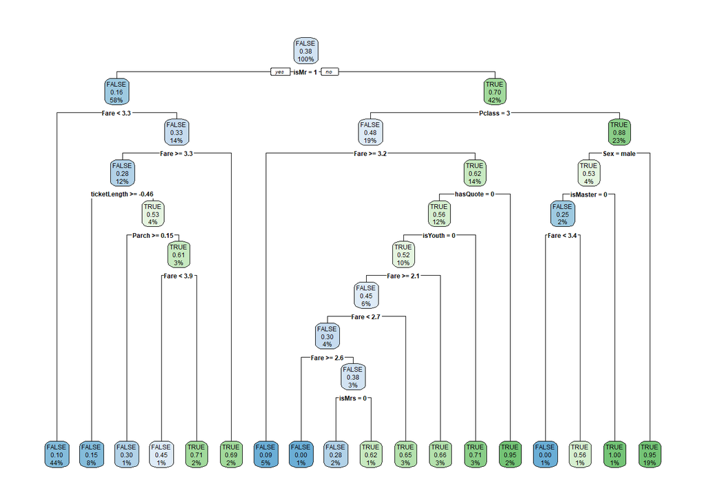

```r
rpart.plot(fitTree)
```

```r
fitTree$cptable
```

```
##            CP nsplit rel error    xerror       xstd
## 1 0.432748538      0 1.0000000 1.0000000 0.04244576
## 2 0.052631579      1 0.5672515 0.5730994 0.03615393
## 3 0.014619883      3 0.4619883 0.4912281 0.03413963
## 4 0.009502924      5 0.4327485 0.4707602 0.03358222
## 5 0.008771930      9 0.3947368 0.4824561 0.03390356
## 6 0.002923977     13 0.3596491 0.4795322 0.03382394
## 7 0.000000000     17 0.3479532 0.4707602 0.03358222
```

```r
# prune tree to reduce complexity and increase interpretability

fitTree <- prune(fitTree, cp = 0.009502924)

confusionMatrix(as.factor(predict(fitTree, type = "class")), as.factor(data.train3$Survived), positive = "TRUE")
```

```
## Confusion Matrix and Statistics
##
##           Reference
## Prediction FALSE TRUE
##      FALSE   491   90
##      TRUE     58  252
##
##                Accuracy : 0.8339
##                  95% CI : (0.8078, 0.8578)
##     No Information Rate : 0.6162
##     P-Value [Acc > NIR] : < 2e-16
##
##                   Kappa : 0.6425
##
##  Mcnemar's Test P-Value : 0.01083
##
##             Sensitivity : 0.7368
##             Specificity : 0.8944
##          Pos Pred Value : 0.8129
##          Neg Pred Value : 0.8451
##              Prevalence : 0.3838
##          Detection Rate : 0.2828
##    Detection Prevalence : 0.3479
##       Balanced Accuracy : 0.8156
##
##        'Positive' Class : TRUE
##
```

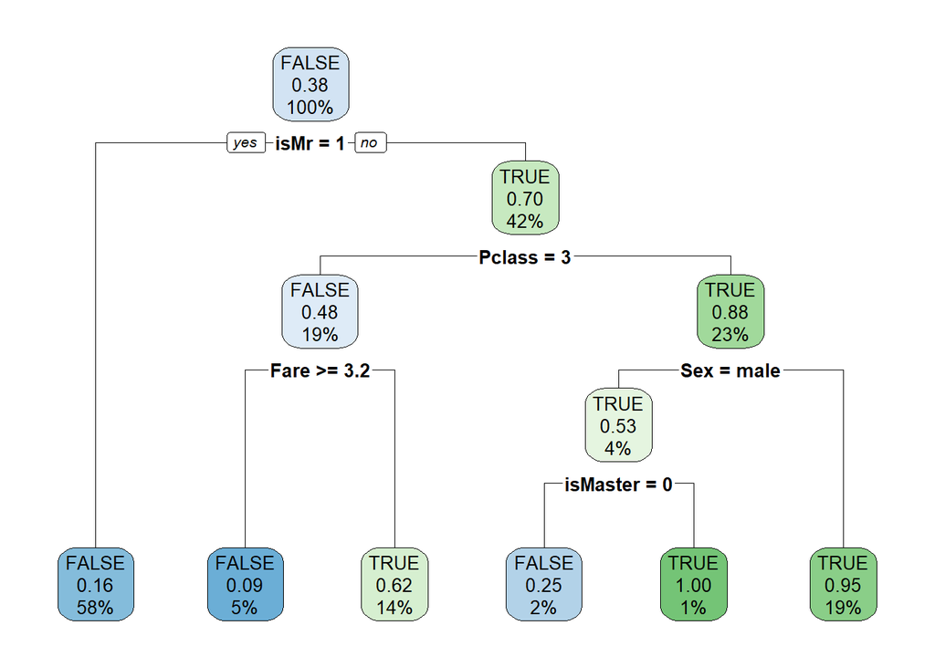

```r
rpart.plot(fitTree)
```

The unpruned tree correctly classifies around 87% of the training data, but it’s too complex, so it’ll likely overfit the data and perform poorly on the test set.

After pruning the tree by manually increasing the complexity parameter, we get a much more easilly interpretable model, and still maintain decent performance (~83%) on the training data. With that said, an individual tree will almost assuredly struggle to generalize to observations beyond its training set, so it’s a good idea to train a few tree-based ensemble models (e.g., random forest, boosted trees) to address potential overfitting.

```r
# generate predictions for the test set
fitTree.predictions <- predict(fitTree, newdata = data.test3, type = "class")
mean(as.logical(fitTree.predictions))
```

```
## [1] 0.3875598
```

#### GLM + Tree Ensemble

```r
# since the GLM and tree have completely different model structures, one might expect that they'd each identify unique characteristics of the signal; hence, it might be useful to create an ensemble of both models

fitSimpleEnsemble.predictions <- ((predict(fitGLM, type = "response") + predict(fitTree, type = "prob")[,2]) / 2) > 0.5
confusionMatrix(as.factor(fitSimpleEnsemble.predictions), as.factor(data.train3$Survived), positive = "TRUE")
```

```
## Confusion Matrix and Statistics
##
##           Reference
## Prediction FALSE TRUE
##      FALSE   493   92
##      TRUE     56  250
##
##                Accuracy : 0.8339
##                  95% CI : (0.8078, 0.8578)
##     No Information Rate : 0.6162
##     P-Value [Acc > NIR] : < 2.2e-16
##
##                   Kappa : 0.6417
##
##  Mcnemar's Test P-Value : 0.004015
##
##             Sensitivity : 0.7310
##             Specificity : 0.8980
##          Pos Pred Value : 0.8170
##          Neg Pred Value : 0.8427
##              Prevalence : 0.3838
##          Detection Rate : 0.2806
##    Detection Prevalence : 0.3434
##       Balanced Accuracy : 0.8145
##
##        'Positive' Class : TRUE
##
```

#### Generate Model Matrices for Use in More Complex Models

```r
# model matrices of the data; used with glmnet and xgboost
X <- model.matrix(Survived ~ . , data.train3)
X.test <- model.matrix(~ . , data.test3)
```

#### LASSO (L1) Regression

```r
# regularization: elastic net with alpha = 1 -> LASSO (L1) regression
# by penalizing high coefficient values, we can limit overfitting of the original GLM
elastic.cv <- cv.glmnet(X, data.train3$Survived, family = "binomial", type.measure = "class", alpha = 1)
fitElastic <- glmnet(X, data.train3$Survived, family = "binomial", type.measure = "class", alpha = 1,
                     lambda = min(elastic.cv$lambda))
confusionMatrix(as.factor(predict(fitElastic, newx = X, type = "class")), as.factor(data.train3$Survived), positive = "TRUE")
```

```
## Confusion Matrix and Statistics
##
##           Reference
## Prediction FALSE TRUE
##      FALSE   482   79
##      TRUE     67  263
##
##                Accuracy : 0.8361
##                  95% CI : (0.8102, 0.8599)
##     No Information Rate : 0.6162
##     P-Value [Acc > NIR] : <2e-16
##
##                   Kappa : 0.6513
##
##  Mcnemar's Test P-Value : 0.3626
##
##             Sensitivity : 0.7690
##             Specificity : 0.8780
##          Pos Pred Value : 0.7970
##          Neg Pred Value : 0.8592
##              Prevalence : 0.3838
##          Detection Rate : 0.2952
##    Detection Prevalence : 0.3704
##       Balanced Accuracy : 0.8235
##
##        'Positive' Class : TRUE
##
```

```r
# generate elastic net predictions on test set (might be useful in an ensemble comprising more complex models)
fitElastic.predictions <- as.logical(predict(fitElastic, newx = X.test, type = "class"))
mean(fitElastic.predictions)
```

```
## [1] 0.4043062
```

#### Random Forest

```r
# random forest; takes a bit longer to train (~ 5-10 mins)

# theoretically reasonable mtry value = sqrt(p), which is about 4 in this case; we'll tune from 1-10, using
# repeated cross-validation and up-/down-sampling to counteract the imbalance in the target values

rfGrid <- expand.grid(.mtry = 2:7)

rfControl <- trainControl(method="repeatedcv", number = 20, repeats = 5, search="grid", sampling = "rose")

fitRandomForest <- train(as.factor(Survived) ~ . , data.train3, method = "rf", tuneGrid = rfGrid, trControl = rfControl)
confusionMatrix(as.factor(predict(fitRandomForest)), as.factor(data.train3$Survived), positive = "TRUE")
```

```
## Confusion Matrix and Statistics
##
##           Reference
## Prediction FALSE TRUE
##      FALSE   470   85
##      TRUE     79  257
##
##                Accuracy : 0.8159
##                  95% CI : (0.7889, 0.8409)
##     No Information Rate : 0.6162
##     P-Value [Acc > NIR] : <2e-16
##
##                   Kappa : 0.6096
##
##  Mcnemar's Test P-Value : 0.6962
##
##             Sensitivity : 0.7515
##             Specificity : 0.8561
##          Pos Pred Value : 0.7649
##          Neg Pred Value : 0.8468
##              Prevalence : 0.3838
##          Detection Rate : 0.2884
##    Detection Prevalence : 0.3771
##       Balanced Accuracy : 0.8038
##
##        'Positive' Class : TRUE
##
```

> The accuracy is only around 82% (recall the individual tree has a training set accuracy of 83-87%), but by blending the effects of many trees one should expect that this overfitting has been significantly addressed and that this model will perform well on the test set, the set that actually matters. With that said, the structure of the model greatly obfuscates the underlying factors in the predictions, making interpretation highly challenging.

```r
# random forest predictions
fitRandomForest.predictions <- as.logical(predict(fitRandomForest, data.test3))
mean(fitRandomForest.predictions)
```

```
## [1] 0.3851675
```

#### eXtreme Boosted Trees

```r
# xgboost applied to trees; training takes significant time with custom tuning grid and extensive resampling procedure

# apply optimized gradient boosting to trees. among the most modern machine learning algorithms

# tuning is not easy, but the performance is, in many cases, unmatched.

# xgbGrid.preliminary <- expand.grid(nrounds = c(20, 40, 60, 80), max_depth = c(1,2,3,4),
#                                eta = c(0.01, 0.1, 0.2, 0.3), gamma = c(0, 1, 10), colsample_bytree = c(0.5, 0.75, 1),
#                                min_child_weight = c(0.5, 1, 2), subsample = c(0.5, 0.75, 1))

# xgbGrid.refined     <- expand.grid(nrounds = c(40,60), max_depth = c(5,7,9),
#                            eta = c(0.01, 0.05, 0.1, 0.2), gamma = c(0,1,3), colsample_bytree = c(0.8, 1),
#                            min_child_weight = c(0.5, 0.75, 1), subsample = c(0.8, 1))

#xgbGrid <- expand.grid(nrounds = c(50, 100, 150), max_depth = c(1, 6, 10),
#                       eta = c(0.01, 0.2, 0.4), gamma = c(0, 1, 5), colsample_bytree = c(0.5, 0.75, 1),
#                       min_child_weight = c(0.4, 0.7, 1), subsample = c(0.4, 0.7, 1))

xgbGrid2 <- expand.grid(nrounds = c(30, 50, 70), max_depth = c(1, 4, 7),
                       eta = c(0.01, 0.1, 0.3), gamma = c(1), colsample_bytree = c(0.8),
                       min_child_weight = c(1), subsample = c(0.8, 1))

xgbControl <- trainControl(method = "repeatedcv", number = 20, repeats = 5, search = "grid", sampling = "rose")

fitXGBoost <- train(as.factor(Survived) ~ . , data.train3,
                         method = "xgbTree", trControl = xgbControl, tuneGrid = xgbGrid2)
```

Should perform at least on par with the random forest model. Again, though predictive power is unmatched, interpretation remains problematic.

```r
confusionMatrix(as.factor(predict(fitXGBoost)), as.factor(data.train3$Survived), positive = "TRUE")
```

```
## Confusion Matrix and Statistics
##
##           Reference
## Prediction FALSE TRUE
##      FALSE   537  150
##      TRUE     12  192
##
##                Accuracy : 0.8182
##                  95% CI : (0.7913, 0.843)
##     No Information Rate : 0.6162
##     P-Value [Acc > NIR] : < 2.2e-16
##
##                   Kappa : 0.584
##
##  Mcnemar's Test P-Value : < 2.2e-16
##
##             Sensitivity : 0.5614
##             Specificity : 0.9781
##          Pos Pred Value : 0.9412
##          Neg Pred Value : 0.7817
##              Prevalence : 0.3838
##          Detection Rate : 0.2155
##    Detection Prevalence : 0.2290
##       Balanced Accuracy : 0.7698
##
##        'Positive' Class : TRUE
##
```

```r
# xgBoost predictions on test set
fitXGBoost.predictions <- as.logical(predict(fitXGBoost, data.test3))
mean(fitXGBoost.predictions)
```

```
## [1] 0.222488
```

### Model Selection

#### Comparing fitRandomForest vs. fitXGBoost

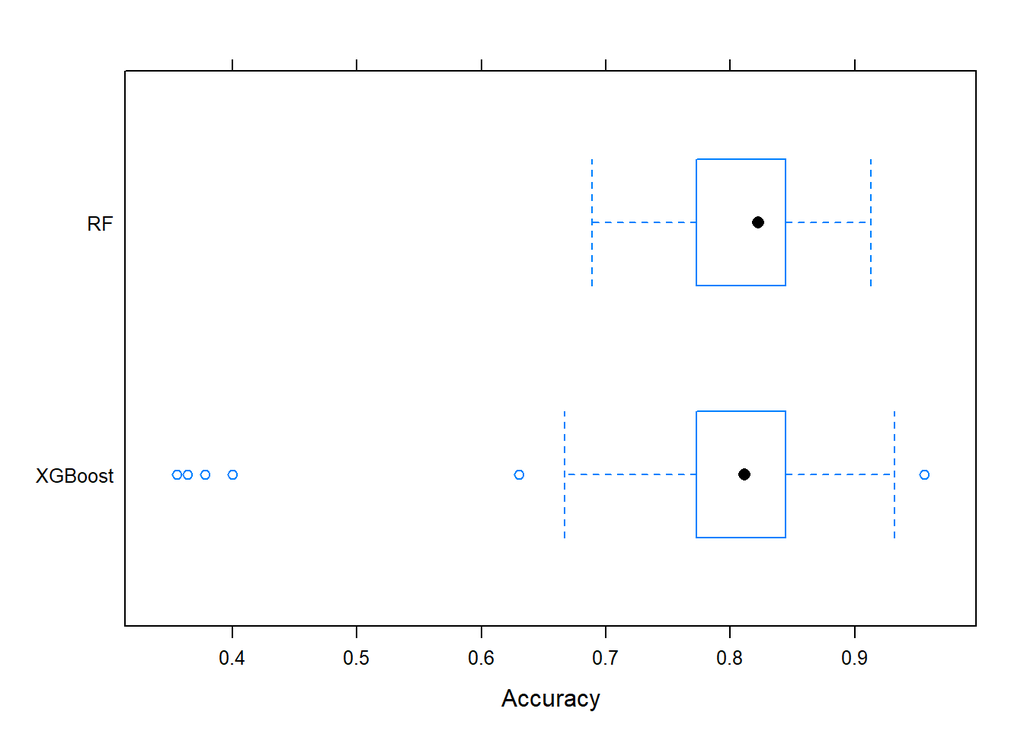

```r
# compare performance of random forest and xgboost models
resamps <- resamples(list(RF = fitRandomForest, XGBoost = fitXGBoost))
bwplot(resamps, metric = "Accuracy")
```

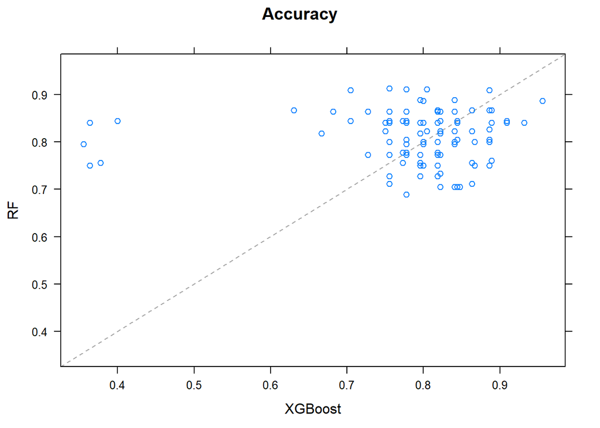

```r
xyplot(resamps)
```

Since we used the same sampling approach to train both the random forest and the xgboost model, we can compare them based on their sets of resamples.

The boxplots look pretty similar: one should expect around an 80% accuracy with each of the models.

With that said, fitXGBoost has a few extreme resamples. Let’s see if we can somehow ascertain some of the latent signal in the model while maintaining the stability of fitRandomForest.

#### Considering an Ensemble

```r
xgb <- as.logical(predict(fitXGBoost, data.test3))
rf <- as.logical(predict(fitRandomForest, data.test3))
table(xgb, rf)
```

```
##        rf
## xgb     FALSE TRUE
##   FALSE   257   68
##   TRUE      0   93
```

The boosted trees model seems to under-predict a TRUE outcome for the target (there were 0 occurences in which fitXGBoost predicted TRUE and fitRandomForest predicted FALSE). With that said, maybe we should create an ensemble that predicts whatever the models predict whenever they agree, but when fitXGBoost says FALSE and fitRandomForest says TRUE, we add in some randomness to convert a few extra FALSE’s over to TRUE’s.

```r
fitEnsemble <- as.data.frame(cbind(xgb, rf))
fitEnsemble$comparison <- fitEnsemble$xgb + fitEnsemble$rf

for (i in 1:nrow(data.test3)) {
  set.seed(as.integer(runif(1) * 100))
  if (fitEnsemble$comparison[i] == 1) {
    fitEnsemble$prediction[i] <- runif(1,0,1) > 0.68
  }
  else {
    fitEnsemble$prediction[i] <- as.logical(fitEnsemble$comparison[i])
  }
}
table(fitEnsemble$prediction, rf)
```

```
##        rf
##         FALSE TRUE
##   FALSE   257   54
##   TRUE      0  107
```

```r
# write the predictions to a .csv file
Survived <- as.numeric(fitEnsemble$prediction)             # fitXGBoost.predictions, fitRandomForest.predictions, fitEnsemble$prediction
submittedResults <- data.frame(PassengerId, Survived)
write.csv(submittedResults, "submission.csv", row.names = FALSE)
```

fitRandomForest, fitXGBoost, and the ensemble, after submitting to Kaggle for assessment on the test set, accurately predicted around 78-80% of the observations, with the random forest model maxing out at 80.1%.

At the time of publication, this accuracy rates in the top 4.54% (2348/51670) of all teams who submitted models for evaluation.

Further hyperparameter tuning, feature generation, alternative models (MARS, GAMs, SVC, NN, etc.), and ensembling would likely improve the model slightly. Perhaps some of these approaches will be attempted in the future.